# Exploratory Visualization on Ford GoBike Service Data

## in SF Bay area (2-2019)

#### Yasser Gharib

**Investigation Overview**

- Bike-sharing service like "Ford GoBike" is one of the rapidly growing transport services around the world, it has gained popularity in major cities across the globe. They allow people in metropolitan areas to rent bicycles for short trips usually within 30 minutes. Ford GoBike has collected a rich amount of data for this bicycle-sharing service from its electronic system in datasets. each dataset includes information about individual rides made in a bikeshare system covering a city for certain time.
- In this project, an python exploratory visualization analysis is performed on the "Ford GoBike" dataset to figureout the relationship between riders featurs, and trips taken features like when (time periods), where (locations) and why are most trips taken.
- Python visualization techniques is used to figure out what is the most influential power variables possess on the bike sharing service.

**Dataset Overview**

- The project Dataset is provided by Ford GoBike sharing service at the greater San Francisco Bay area for ONE month (February 2019) which have thousands of bikes and trips features available. it’s the most fun, convenient, and affordable way to explore the region.

**Setup Environment**

- Initialization
- Set visualization style
- Read data
- Dataset Structure
- This data set includes information about individual rides made in a bikeshare system covering the greater San Francisco Bay area for ONE month (February 2019) with 183,412 trips and 16 features.
- Examine DataFrame

**The 16 Features:**

- duration_sec: This has been given to us in seconds. A more natural unit of analysis will be if all the trip durations are given in minutes.
- start_time, end_time: The time variables are for one month (February 2019), it is string, so for the analysis,it need to convert to datetime format and broken down into time of day, day of the week. We'll use start_time and durations only (end_time to calculate duration which i alrady have it)
- The dataset provides membership birth year, so ages can be derived by using the year of the dataset, 2019, minus the membership birth year.
- start_station_id, end_station_id: it is float64, it tell use the start and end stations id for each trip.
- start_station_name, end_station_name: it tell use the start and end stations name for each trip.
- (start_station_latitude, start_station_longitude) (end_station_latitude,end_station_longitude) that for putting the start station and end one on map or GIS, google map or calculate the stright line distant between start and end station (we'll not use it).
- bike_id: int64,it is id No., telling which bike is used (we may use sum of duration time for each bick for maintance schaduale)
- user_type: The data uses 'Subscriber' and 'Customer'.
- member_birth_year : float64, The dataset provides membership birth year, so ages can be derived by using the year of the dataset, 2019, to divide by the membership birth year.
- member_gender: Male vs. Female vs. Others.
- bike_share_for_all_trip: yes/no , tell use the bick ability to share for all trip or not.

**All features for the Trip like: start_time, end_time, duration_sec, start_station_name, end_station_name, start_station_latitude, start_station_longitude, end_station_latitude,end_station_longitude, which bick in bike_id**

but some for the bick like: bike_id, bike_share_for_all_trip

and other for user like: user gender (member_gender), age (member_birth_year), user_type

**What is the main interesting dataset features that support the investigation?**

in this dataset,

The most interested features will include:

- Pick featues (start time/location, end time/location and duration)
- with Riders characteristics (age, gender, and user_type)
- in figuring out the questions answer of **when?, where? and why?** most trips are taken.

#### Data Cleansing

- Updating data types
- Checking for missing values and duplicates
- Number of Missing Values rows is 8460 from 183412 rows, ie: 4.612566244302445%
- Missing values were found in 6 features:
- member_gender, member_birth_year, start_station_id, start_station_name, end_station_id, end_station_name.
- Drop missing data row due to low % (4.61%)
- Check if duplicates exist:
  - No duplicates exist
- For any Sckew chart, Transformation to like Normal Distribution will be done.

## Deriven Data

**Generate new field for day period (time period) from `start_time`**

**Generate new field for Week Day from `start_time`**

**for visualization, Order of time period, and weekday**

**for visualization wise, more Generating for new field will be done in its place.**

### Filter data to include reasonable member age range

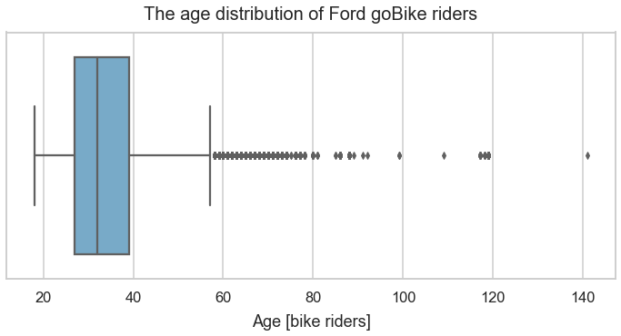

There are outliers. Age from 18 to 55 takes 95% of the users. So, it's logical to remove users more than 60 years old. There were users more than 100 years old.

### Working with The most stations trips or with all station are better?

**Start stations: there are 329 with different trafics.**

**The most trafic station (the first 7 station on the graph) will be used in this invistigation project.**

**Subset the dataset by keeping only top 7 locations with high trips**

**Keeping only top 7 locations with high trips**

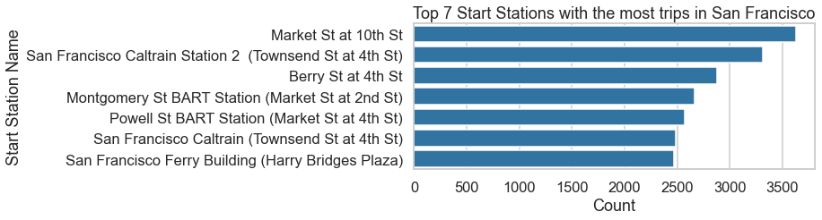

## Where and Why most trips are taken?

After checking the top (most trips) 7 start and end stations in San Francisco are taken becouse this most stations were connect to public transportations such as CalTrain, Metro (Berry) stations , Ferry building and Market Street.

The top (most trips) 7 start and end stations are looks like the same,

- Market St at 10th St
- San Francisco Caltrain Station 2 (Townsend St at 4th St)
- Berry St at 4th St
- Montgomery St BART Station (Market St at 2nd St)
- Powell St BART Station (Market St at 4th St)
- San Francisco Ferry Building (Harry Bridges Plaza)
- San Francisco Caltrain (Townsend St at 4th St)

# When the most trips are taken?¶

## Univariate Exploration¶

#### by looking into the start time and start location of this dataset.

#### The distribution of time of day, weekday after subsetting, regenerate:

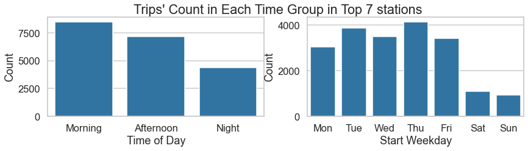

#### In these top 7 trips stations, base on the above figures, we found:

- During the day, there are more trips in the morning and afternoon than the night. It probably because of rush hours. Also, the number of trips in the afternoon is slightly less than the morning and beger than night. may be bick riders go in the morning and come back home in afternoon, and might not be back in the night.
- It makes sense that there are more trips during the weekdays and less trips during the weekends because of working schedule.

## Bivariate Exploration¶

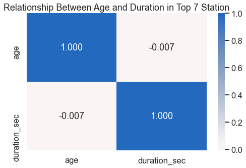

Based on the correlation, age is slightly negative correlated with duration, ie. age and duration is negatively correlated. in this dataset, the major population of age is between 30 and 40 years old and We have less samples in the older population.

##### Categorical variables by plotting countplot: top 7 stations by times (time of day, weekdays)

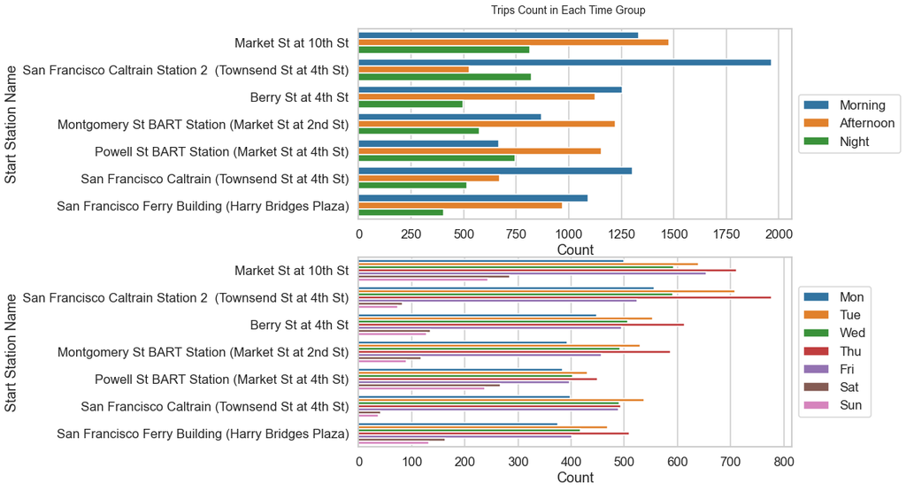

After breaking down into each station,

- Time of day: morning is not necessary the period of time with most trips. 4 stations have the most trips during the morning and another 3 stations has the most trips during the afternoon. It needs to be investigated more.
- Day of week: weekdays (Monday, Tuesday, Wednesday, Thursday and Friday) have the most trips than weekends. Compared to other weekdays, Sunday has less trips and Some stations' weekends have more trips than other stations (even their trips are still less than weekdays') might because these stations are close to tourist attractions. But all of points need to be taken a deeper look.

### Observed relationships in bivariate exploration.

In the top 7 stations, look into the attributes' times:

## Multivariate Exploration¶

The most interesting variables are in locations and time with most trips. Now, we 'll study the effects and trends after adding third or more variables.

**3 categorical variables using countplot: time of day: morning, afternoon, night between customers and subscribers**

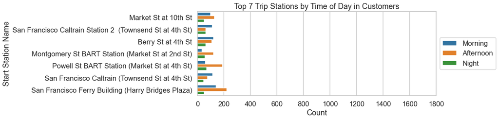

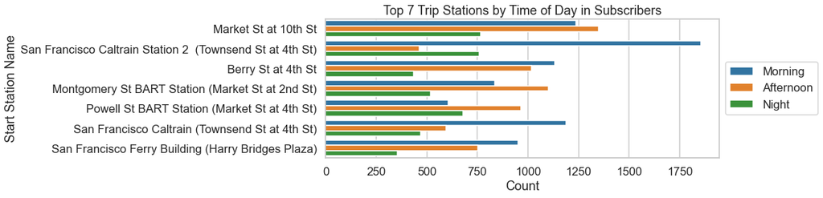

Time of Day: there are more trips in the morning or afternoon no matter in customers or subscribers.